# Danish Kings

Olivia Englund Kusk

2026-13-03

```r
knitr::opts_chunk$set(echo = TRUE)
```

The task here is to load your Danish Monarchs csv into R using the `tidyverse` toolkit, calculate and explore the kings’ duration of reign with pipes `%>%` in `dplyr` and plot it over time.

## Load the kings

Make sure to first create an `.Rproj` workspace with a `data/` folder where you place either your own dataset or the provided `kings.csv` dataset.

1. Look at the dataset that are you loading and check what its columns are separated by? (hint: open it in plain text editor to see)

List what is the

separator: “;”

2. Create a `kings` object in R with the different functions below and inspect the different outputs.
- `read.csv()`
- `read_csv()`
- `read.csv2()`
- `read_csv2()`

```r
library(tidyverse)
library(here)
# FILL IN THE CODE BELOW and review the outputs
kings1 <- read.csv("data/Monarker.csv")
kings1
```

```
##    Konge_navn.Kongerække.Fødselsår.Dødsår.Regeringtids_Start.Regeringtids_Slut.Antal_regeringsår.Egne_noter..
## 1                                                                        Gorm_Den_Gamle;1;NA;958;958;NA;NA;;;
## 2                                                                        Harald_Blåtand;2;NA;987;987;NA;NA;;;
## 3                                                                    Svend_1_Tveskæg;3;963;1014;NA;1014;NA;;;
## 4                                                         Harald_2;4;NA;1018;1014;1018;4;Ikke sikker dødsår;;
## 5                                                                 Kund_1_Den_Store;5;995;1035;1018;1035;17;;;
## 6                                                                        Hardeknud;6;1020;1042;1035;1042;7;;;
## 7                                          Svend_2_Estridesn;8;1020;1076;1047;1074;27;Ikke sikker fødselsår;;
## 8                                                                  Magnus_Den_Gode;7;1024;1047;1042;1047;5;;;
## 9                                               Harald_3_Hen ;9;1040;1080;1074;1080;6;Ikke sikker fødselsår;;
## 10                                        Kund_2_Den_Helling;10;1042;1086;1080;1086;6;Ikke sikker fødselsår;;
## 11                                             Oluf_1_Hunger;11;1050;1095;1086;1095;9;Ikke sikker fødselsår;;
## 12                                             Erik_1_Ejegod;12;1056;1103;1095;1103;8;Ikke sikker fødselsår;;
## 13                                                    Niels;13;1065;1134;1104;1134;30;Ikke sikker fødselsår;;
## 14                                              Erik_2_Emune;14;1090;1137;1134;1137;3;Ikke sikker fødselsår;;
```

[output cut: 44 more lines]

```r
kings2 <- read_csv("data/Monarker.csv")
kings2
```

```
## # A tibble: 58 × 1
##    Konge_navn;Kongerække;Fødselsår;Dødsår;Regeringtids_Start;Regeringtids_Slut…¹
##    <chr>
##  1 Gorm_Den_Gamle;1;NA;958;958;NA;NA;;;
##  2 Harald_Blåtand;2;NA;987;987;NA;NA;;;
##  3 Svend_1_Tveskæg;3;963;1014;NA;1014;NA;;;
##  4 Harald_2;4;NA;1018;1014;1018;4;Ikke sikker dødsår;;
##  5 Kund_1_Den_Store;5;995;1035;1018;1035;17;;;
##  6 Hardeknud;6;1020;1042;1035;1042;7;;;
##  7 Svend_2_Estridesn;8;1020;1076;1047;1074;27;Ikke sikker fødselsår;;
##  8 Magnus_Den_Gode;7;1024;1047;1042;1047;5;;;
##  9 Harald_3_Hen ;9;1040;1080;1074;1080;6;Ikke sikker fødselsår;;
## 10 Kund_2_Den_Helling;10;1042;1086;1080;1086;6;Ikke sikker fødselsår;;
## # ℹ 48 more rows
## # ℹ abbreviated name:
## #   ¹`Konge_navn;Kongerække;Fødselsår;Dødsår;Regeringtids_Start;Regeringtids_Slut;Antal_regeringsår;Egne_noter;;`
```

```r
kings3 <- read.csv2("data/Monarker.csv")
kings3
```

```
##                 Konge_navn Kongerække Fødselsår Dødsår Regeringtids_Start
## 1           Gorm_Den_Gamle          1        NA    958                958
## 2           Harald_Blåtand          2        NA    987                987
## 3          Svend_1_Tveskæg          3       963   1014                 NA
## 4                 Harald_2          4        NA   1018               1014
## 5         Kund_1_Den_Store          5       995   1035               1018
## 6                Hardeknud          6      1020   1042               1035
## 7        Svend_2_Estridesn          8      1020   1076               1047
## 8          Magnus_Den_Gode          7      1024   1047               1042
## 9            Harald_3_Hen           9      1040   1080               1074
## 10      Kund_2_Den_Helling         10      1042   1086               1080
## 11           Oluf_1_Hunger         11      1050   1095               1086
## 12           Erik_1_Ejegod         12      1056   1103               1095
## 13                   Niels         13      1065   1134               1104
## 14            Erik_2_Emune         14      1090   1137               1134
```

[output cut: 162 more lines]

```r
kings4 <- read_csv2( "data/Monarker.csv")
```

```
## ℹ Using "','" as decimal and "'.'" as grouping mark. Use `read_delim()` for more control.
```

```r
kings4
```

```
## # A tibble: 58 × 10
##    Konge_navn   Kongerække Fødselsår Dødsår Regeringtids_Start Regeringtids_Slut
##    <chr>             <dbl>     <dbl>  <dbl>              <dbl>             <dbl>
##  1 Gorm_Den_Ga…          1        NA    958                958                NA
##  2 Harald_Blåt…          2        NA    987                987                NA
##  3 Svend_1_Tve…          3       963   1014                 NA              1014
##  4 Harald_2              4        NA   1018               1014              1018
##  5 Kund_1_Den_…          5       995   1035               1018              1035
##  6 Hardeknud             6      1020   1042               1035              1042
##  7 Svend_2_Est…          8      1020   1076               1047              1074
##  8 Magnus_Den_…          7      1024   1047               1042              1047
##  9 Harald_3_Hen          9      1040   1080               1074              1080
## 10 Kund_2_Den_…         10      1042   1086               1080              1086
## # ℹ 48 more rows
## # ℹ 4 more variables: Antal_regeringsår <dbl>, Egne_noter <chr>, ...9 <lgl>,
## #   ...10 <lgl>
```

Answer: 1. Which of these functions is a `tidyverse` function? Read data with it below into a `kings` object #nr 4 cvs_ is a tidyverse (a tibble output)

2. What is the result of running `class()` on the `kings` object created with a tidyverse function. # The result shows that the object is a tibble created by tidyverse. # class(kings) returns: “spec_tbl_df”, “tbl_df”, “tbl”, “data.frame”
3. How many columns does the object have when created with these different functions? # The dataset contains 10 columns (shown as 58 x 10 in the tibble output)
4. Show the dataset so that we can see how R interprets each column # glimpse() shows how R interprets each column (character, numeric etc.) glimpse(kings)

```r
# COMPLETE THE BLANKS BELOW WITH YOUR CODE, then turn the 'eval' flag in this chunk to TRUE.
class(kings4)
```

```
## [1] "spec_tbl_df" "tbl_df"      "tbl"         "data.frame"
```

```r
glimpse(kings4)
```

```
## Rows: 58
## Columns: 10
## $ Konge_navn         <chr> "Gorm_Den_Gamle", "Harald_Blåtand", "Svend_1_Tveskæ…
## $ Kongerække         <dbl> 1, 2, 3, 4, 5, 6, 8, 7, 9, 10, 11, 12, 13, 14, 15, …
## $ Fødselsår          <dbl> NA, NA, 963, NA, 995, 1020, 1020, 1024, 1040, 1042,…
## $ Dødsår             <dbl> 958, 987, 1014, 1018, 1035, 1042, 1076, 1047, 1080,…
## $ Regeringtids_Start <dbl> 958, 987, NA, 1014, 1018, 1035, 1047, 1042, 1074, 1…
## $ Regeringtids_Slut  <dbl> NA, NA, 1014, 1018, 1035, 1042, 1074, 1047, 1080, 1…
## $ Antal_regeringsår  <dbl> NA, NA, NA, 4, 17, 7, 27, 5, 6, 6, 9, 8, 30, 3, 9, …
## $ Egne_noter         <chr> NA, NA, NA, "Ikke sikker dødsår", NA, NA, "Ikke sik…
## $ ...9               <lgl> NA, NA, NA, NA, NA, NA, NA, NA, NA, NA, NA, NA, NA,…
## $ ...10              <lgl> NA, NA, NA, NA, NA, NA, NA, NA, NA, NA, NA, NA, NA,…
```

```r
head(kings4)
```

```
## # A tibble: 6 × 10
##   Konge_navn    Kongerække Fødselsår Dødsår Regeringtids_Start Regeringtids_Slut
##   <chr>              <dbl>     <dbl>  <dbl>              <dbl>             <dbl>
## 1 Gorm_Den_Gam…          1        NA    958                958                NA
## 2 Harald_Blåta…          2        NA    987                987                NA
## 3 Svend_1_Tves…          3       963   1014                 NA              1014
## 4 Harald_2               4        NA   1018               1014              1018
## 5 Kund_1_Den_S…          5       995   1035               1018              1035
## 6 Hardeknud              6      1020   1042               1035              1042
## # ℹ 4 more variables: Antal_regeringsår <dbl>, Egne_noter <chr>, ...9 <lgl>,
## #   ...10 <lgl>
```

## Calculate the duration of reign for all the kings in your table

You can calculate the duration of reign in years with `mutate` function by subtracting the equivalents of your `startReign` from `endReign` columns and writing the result to a new column called `duration`. But first you need to check a few things:

- Is your data messy? Fix it before re-importing to R
- Do your start and end of reign columns contain NAs? Choose the right strategy to deal with them: `na.omit()`, `na.rm=TRUE`, `!is.na()`

Create a new column called `duration` in the kings dataset, utilizing the `mutate()` function from tidyverse. Check with your group to brainstorm the options.

```r
kings_duration <- kings4 %>%
  mutate(duration = Regeringtids_Slut - Regeringtids_Start)
head(kings_duration)
```

```
## # A tibble: 6 × 11
##   Konge_navn    Kongerække Fødselsår Dødsår Regeringtids_Start Regeringtids_Slut
##   <chr>              <dbl>     <dbl>  <dbl>              <dbl>             <dbl>
## 1 Gorm_Den_Gam…          1        NA    958                958                NA
## 2 Harald_Blåta…          2        NA    987                987                NA
## 3 Svend_1_Tves…          3       963   1014                 NA              1014
## 4 Harald_2               4        NA   1018               1014              1018
## 5 Kund_1_Den_S…          5       995   1035               1018              1035
## 6 Hardeknud              6      1020   1042               1035              1042
## # ℹ 5 more variables: Antal_regeringsår <dbl>, Egne_noter <chr>, ...9 <lgl>,
## #   ...10 <lgl>, duration <dbl>
```

## Calculate the average duration of reign for all rulers

Do you remember how to calculate an average on a vector object? If not, review the last two lessons and remember that a column is basically a vector. So you need to subset your `kings` dataset to the `duration` column. If you subset it as a vector you can calculate average on it with `mean()` base-R function. If you subset it as a tibble, you can calculate average on it with `summarize()` tidyverse function. Try both ways!

- You first need to know how to select the relevant `duration` column. What are your options?
- Is your selected `duration` column a tibble or a vector? The `mean()` function can only be run on a vector. The `summarize()` function works on a tibble.
- Are you getting an error that there are characters in your column? Coerce your data to numbers with `as.numeric()`.
- Remember to handle NAs: `mean(X, na.rm=TRUE)`

```r
kings_duration %>%
  summarize(avg_duration = mean(duration, na.rm = TRUE))
```

```
## # A tibble: 1 × 1
##   avg_duration
##          <dbl>
## 1         19.1
```

Den gennemsnitlige regeringstid for danske konger i datasættet er ca. 19 år.

## How many and which kings enjoyed a longer-than-average duration of reign?

You have calculated the average duration above. Use it now to `filter()` the `duration` column in `kings` dataset. Display the result and also count the resulting rows with `count()`

```r
kings_duration %>%
  filter(duration > mean(duration, na.rm = TRUE)) %>%
  count()
```

```
## # A tibble: 1 × 1
##       n
##   <int>
## 1    24
```

24 danske konger regerede længere end gennemsnittet.

## How many days did the three longest-ruling monarchs rule?

- Sort kings by reign `duration` in the descending order. Select the three longest-ruling monarchs with the `slice()` function
- Use `mutate()` to create `Days` column where you calculate the total number of days they ruled
- BONUS: consider the transition year (with 366 days) in your calculation!

```r
longest_monarch <- kings_duration %>%
  filter(duration>mean(duration,na.rm = TRUE)) %>%
  arrange(desc(duration)) %>%
  slice(1:3)

longest_monarch %>%
  mutate(Days=duration*365)
```

```
## # A tibble: 3 × 12
##   Konge_navn    Kongerække Fødselsår Dødsår Regeringtids_Start Regeringtids_Slut
##   <chr>              <dbl>     <dbl>  <dbl>              <dbl>             <dbl>
## 1 Christian_4           39      1577   1648               1588              1648
## 2 Margrethe_2           53      1940     NA               1972              2024
## 3 Erik_7_af_Po…         31      1382   1439               1396              1439
## # ℹ 6 more variables: Antal_regeringsår <dbl>, Egne_noter <chr>, ...9 <lgl>,
## #   ...10 <lgl>, duration <dbl>, Days <dbl>
```

De tre længst regenter var Erik d. 7 af Pommern med 15695 dage, Margrethe d. 2 med 18980 dage og Christian d. 4 med 21900 dage.

## Challenge: Plot the kings’ duration of reign through time

What is the long-term trend in the duration of reign among Danish monarchs? How does it relate to the historical violence trends ?

- Try to plot the duration of reign column in `ggplot` with `geom_point()` and `geom_smooth()`
- In order to peg the duration (which is between 1-99) somewhere to the x axis with individual centuries, I recommend creating a new column `midyear` by adding to `startYear` the product of `endYear` minus the `startYear` divided by two (`startYear + (endYear-startYear)/2`).
- Now you can plot the kings dataset, plotting `midyear` along the x axis and `duration` along y axis
- BONUS: add a title, nice axis labels to the plot and make the theme B&W and font bigger to make it nice and legible!

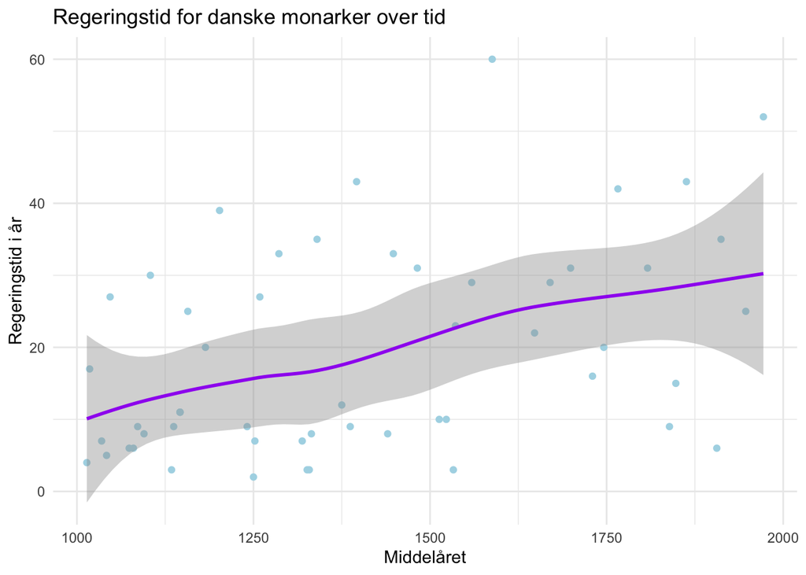

```r
Midyear_Monarch <- kings_duration %>%
  mutate(Midyear=Regeringtids_Slut-Antal_regeringsår) %>%
  ggplot(aes(x=Midyear, y=Antal_regeringsår))+
  geom_point(color="Lightblue")+
  geom_smooth(color="Purple")+
  labs(title = "Regeringstid for danske monarker over tid",
       x="Middelåret",
       y= "Regeringstid i år")+
  theme_minimal()

Midyear_Monarch
```

```r
ggsave(here("figures","Monarch.png"), plot = Midyear_Monarch, height = 3, width = 6)
```